# Keystone_Species

You have inherited a project from a former PhD student who was studying the relationship between water quality and predatory fish assemblages along the Ross River Estuary gradient. Unfortunately, their data management was entirely manual, and the files are a disaster. Your mission is to write a single, reproducible R script (or .qmd) that ingests this mess, cleans it, joins it into a single master dataset, and produces a publication-ready visualisation of the estuary’s ecology.

# Introduction

Here I am going to wrangling in messy data, and produce a publication-ready visualisation of the estuary’s ecology.the data is split across 4 different files

# Phase 1: Ingestion and Decontamination

Load libraries

```r
library(ggplot2)
library(tidyverse)
library(readr)
library(readxl)
library(lubridate)
```

Load data sets:

catch data is split acorss 4 sheetsin one excel file: loading individually

```r
#estrury catch dat with 4 sheets, each sheet is different site
catch1<- read_excel("estuary_catch_log.xlsx", sheet =1)
catch2<- read_excel("estuary_catch_log.xlsx", sheet =2)
catch3<- read_excel("estuary_catch_log.xlsx", sheet =3)
catch4<- read_excel("estuary_catch_log.xlsx", sheet =4)   ##Excel Tab Iteration

catch_data <- bind_rows(catch1, catch2, catch3, catch4)

rm(catch1, catch2, catch3, catch4) # Clean up the environment
```

```r
metadata <- read_csv("estuary_metadata.csv")
sensory_raw <- read_csv("estuary_sonde_data.csv")
species_dictionary <- read_csv("species_dictionary.csv")
```

Exploring the data sets

Catch data:

```r
head(catch_data)
```

```
## # A tibble: 6 × 4
##   site       date                species       count
##   <chr>      <dttm>              <chr>         <dbl>
## 1 Lower_ross 2026-05-01 00:00:00 barramundi        6
## 2 Lower_ross 2026-05-01 00:00:00 MANGROVE JACK     3
## 3 Lower_ross 2026-05-01 00:00:00 bream             4
## 4 Lower_ross 2026-05-01 00:00:00 flathead          2
## 5 Lower_ross 2026-05-02 00:00:00 barramundi        1
## 6 Lower_ross 2026-05-02 00:00:00 MANGROVE JACK     1
```

```r
glimpse(catch_data)
```

```
## Rows: 427
## Columns: 4
## $ site    <chr> "Lower_ross", "Lower_ross", "Lower_ross", "Lower_ross", "Lower…
## $ date    <dttm> 2026-05-01, 2026-05-01, 2026-05-01, 2026-05-01, 2026-05-02, 2…
## $ species <chr> "barramundi", "MANGROVE JACK", "bream", "flathead", "barramund…
## $ count   <dbl> 6, 3, 4, 2, 1, 1, 3, 3, 2, 3, 1, 8, 4, 1, 1, 2, 1, 2, 4, 2, 2,…
```

```r
str(catch_data)
```

```
## tibble [427 × 4] (S3: tbl_df/tbl/data.frame)
##  $ site   : chr [1:427] "Lower_ross" "Lower_ross" "Lower_ross" "Lower_ross" ...
##  $ date   : POSIXct[1:427], format: "2026-05-01" "2026-05-01" ...
##  $ species: chr [1:427] "barramundi" "MANGROVE JACK" "bream" "flathead" ...
##  $ count  : num [1:427] 6 3 4 2 1 1 3 3 2 3 ...
```

These outputs don’t show how many levels of species and site there are. have 2 options: first explicitly by using distinct() or convert into factors and use levels() to see how many levels of each factor there are.

String Standardisation catch data

```r
catch_data |>
  distinct(site)
```

```
## # A tibble: 4 × 1
##   site
##   <chr>
## 1 Lower_ross
## 2 Mid_Ross
## 3 ROSS MOUTH
## 4 Upper Ross
```

```r
catch_data |>
  distinct(species)
```

```
## # A tibble: 4 × 1
##   species
##   <chr>
## 1 barramundi
## 2 MANGROVE JACK
## 3 bream
## 4 flathead
```

We have 4 species within our dataset as well as 4 sites located at different points on the ross river. What I need to do:

- fix the names of the sites into reasonable order
- can load metadata now or later but will need to look at the metadata to see how the sites are ordered along the estuary gradient. I will load the metadata now to see how the sites are ordered along the estuary gradient.
- Fix species names, I will do this by joining the catch data with the species dictionary, which will give me the correct species names and also the common names for each species. I will do this by using a left join, which will keep all the rows in the catch data and add the common names from the species dictionary.

Metadata - inspection

```r
head(metadata)
```

```
## # A tibble: 4 × 4
##   site_name    lat   lon zone
##   <chr>      <dbl> <dbl> <chr>
## 1 Upper_Ross -19.3  147. Upstream
## 2 mid_ross   -19.3  147. Middle
## 3 LOWER ROSS -19.3  147. Downstream
## 4 ross_mouth -19.2  147. Marine
```

```r
glimpse(metadata)
```

```
## Rows: 4
## Columns: 4
## $ site_name <chr> "Upper_Ross", "mid_ross", "LOWER ROSS", "ross_mouth"
## $ lat       <dbl> -19.31, -19.28, -19.26, -19.25
## $ lon       <dbl> 146.74, 146.78, 146.81, 146.83
## $ zone      <chr> "Upstream", "Middle", "Downstream", "Marine"
```

Site names are also super messy so will need to fix and standardize this across the data sets

Standardise site and speices names across data sets

```r
catch_data <- catch_data |>
  mutate(
    site = str_to_lower(str_trim(site)),
    site = str_replace_all(site, " ", "_")) |>
  # Convert all chr to fct
  mutate(across(where(is.character), as_factor)
  )

metadata <- metadata |>
  mutate(
    site_name = str_to_lower(str_trim(site_name)),
    site_name = str_replace_all(site_name, " ", "_")) |>
  # Convert all chr to fct
  mutate(across(where(is.character), as_factor)
  )
```

Recheck

```r
catch_data |>
  str()
```

```
## tibble [427 × 4] (S3: tbl_df/tbl/data.frame)
##  $ site   : Factor w/ 4 levels "lower_ross","mid_ross",..: 1 1 1 1 1 1 1 1 1 1 ...
##  $ date   : POSIXct[1:427], format: "2026-05-01" "2026-05-01" ...
##  $ species: Factor w/ 4 levels "barramundi","MANGROVE JACK",..: 1 2 3 4 1 2 3 4 2 4 ...
##  $ count  : num [1:427] 6 3 4 2 1 1 3 3 2 3 ...
```

```r
 #catch_data |>
#   distinct(site)
glimpse(metadata)
```

```
## Rows: 4
## Columns: 4
## $ site_name <fct> upper_ross, mid_ross, lower_ross, ross_mouth
## $ lat       <dbl> -19.31, -19.28, -19.26, -19.25
## $ lon       <dbl> 146.74, 146.78, 146.81, 146.83
## $ zone      <fct> Upstream, Middle, Downstream, Marine
```

Species dictionary - Taxonomic Dictionary

```r
head(species_dictionary)
```

```
## # A tibble: 4 × 2
##   common_name   scientific_name
##   <chr>         <chr>
## 1 barramundi    Lates calcarifer
## 2 mangrove_jack Lutjanus argentimaculatus
## 3 bream         Acanthopagrus spp.
## 4 flathead      Platycephalus spp.
```

```r
glimpse(species_dictionary)
```

```
## Rows: 4
## Columns: 2
## $ common_name     <chr> "barramundi", "mangrove_jack", "bream", "flathead"
## $ scientific_name <chr> "Lates calcarifer", "Lutjanus argentimaculatus", "Acan…
```

```r
species_dictionary|>
  distinct(common_name)
```

```
## # A tibble: 4 × 1
##   common_name
##   <chr>
## 1 barramundi
## 2 mangrove_jack
## 3 bream
## 4 flathead
```

Standardise variable in the catch log to match dictionaries

```r
catch_data <- catch_data |>
  mutate(
    site = str_to_lower(str_trim(site)),
    site = str_replace_all(site, " ", "_"),
    species = str_to_lower(str_trim(species)),
    species = str_replace_all(species, " ", "_")
  )
```

Check common names in catch log match those in the taxonomic dictionary

```r
catch_data |>
  distinct(species)
```

```
## # A tibble: 4 × 1
##   species
##   <chr>
## 1 barramundi
## 2 mangrove_jack
## 3 bream
## 4 flathead
```

```r
species_dictionary |>
  distinct(common_name)
```

```
## # A tibble: 4 × 1
##   common_name
##   <chr>
## 1 barramundi
## 2 mangrove_jack
## 3 bream
## 4 flathead
```

Taxonomic Translation (Common to Scientific)

```r
catch_data <- catch_data |>
  mutate(common_name = species) |>
  left_join(species_dictionary, by = join_by(common_name)) |>
  select(site, species, date, common_name, scientific_name, count)
```

Checking sensor data

```r
head(sensory_raw)
```

```
## # A tibble: 6 × 5
##   site       timestamp        temperature salinity turbidity
##   <chr>      <chr>                  <dbl>    <dbl>     <dbl>
## 1 upper_ross 01/05/2026 00:00        23.7     4.05      6.49
## 2 mid_ross   01/05/2026 00:00        24.1    15.7      49.2
## 3 lower_ross 01/05/2026 00:00        24.2    28.9      48.1
## 4 ross_mouth 01/05/2026 00:00        24.6    33.9      49.8
## 5 upper_ross 01/05/2026 00:15        26.1     3.96     25.2
## 6 mid_ross   01/05/2026 00:15        24.6    12.1      34.8
```

```r
glimpse(sensory_raw)
```

```
## Rows: 11,520
## Columns: 5
## $ site        <chr> "upper_ross", "mid_ross", "lower_ross", "ross_mouth", "upp…
## $ timestamp   <chr> "01/05/2026 00:00", "01/05/2026 00:00", "01/05/2026 00:00"…
## $ temperature <dbl> 23.71379, 24.13302, 24.23558, 24.64147, 26.06955, 24.62576…
## $ salinity    <dbl> 4.054812, 15.742962, 28.934938, 33.891350, 3.962750, 12.05…
## $ turbidity   <dbl> 6.489046, 49.216967, 48.135752, 49.811493, 25.184739, 34.8…
```

```r
str(sensory_raw)
```

```
## spc_tbl_ [11,520 × 5] (S3: spec_tbl_df/tbl_df/tbl/data.frame)
##  $ site       : chr [1:11520] "upper_ross" "mid_ross" "lower_ross" "ross_mouth" ...
##  $ timestamp  : chr [1:11520] "01/05/2026 00:00" "01/05/2026 00:00" "01/05/2026 00:00" "01/05/2026 00:00" ...
##  $ temperature: num [1:11520] 23.7 24.1 24.2 24.6 26.1 ...
##  $ salinity   : num [1:11520] 4.05 15.74 28.93 33.89 3.96 ...
##  $ turbidity  : num [1:11520] 6.49 49.22 48.14 49.81 25.18 ...
##  - attr(*, "spec")=
##   .. cols(
##   ..   site = col_character(),
##   ..   timestamp = col_character(),
##   ..   temperature = col_double(),
##   ..   salinity = col_double(),
##   ..   turbidity = col_double()
##   .. )
##  - attr(*, "problems")=<externalptr>
```

```r
summary(sensory_raw)
```

```
##      site            timestamp          temperature       salinity
##  Length:11520       Length:11520       Min.   :18.14   Min.   :-2.224
##  Class :character   Class :character   1st Qu.:23.00   1st Qu.: 8.268
##  Mode  :character   Mode  :character   Median :24.01   Median :22.255
##                                        Mean   :24.00   Mean   :20.462
##                                        3rd Qu.:24.98   3rd Qu.:32.500
##                                        Max.   :29.61   Max.   :37.773
##    turbidity
##  Min.   :-999.00
##  1st Qu.:  11.59
##  Median :  24.36
##  Mean   : -24.87
##  3rd Qu.:  37.04
##  Max.   :  50.00
```

Need to fix errors in salinity (negative numbers) and turbidity (-999), Both variables are numeric. Timestamp is in character format and needs to be converted to date time format. Site names are also messy and need to be standardized across the data sets.

Clean up sensor data

```r
sensor_data <- sensory_raw|>
  mutate(
    #parse the messy charcter string to correct date - (day/month/year hour:minute)
    datetime = dmy_hm(timestamp),

    #convert the -999.0 hardware error to a treu Na
    turbidity = na_if(turbidity, -999.0),

    #convert the negative salinity values to true NA
    salinity = if_else(salinity < 0, NA, salinity),  # this will replace any negative salinity values with NA, and any positive values will remain as the unchanged salinity values
  )
```

# Phase 2: The Relational Architecture

Summarise 15 min sensor data into daily means

```r
sensor_daily <-
  sensor_data |>
  mutate(date =as_date(floor_date(datetime,"day"))) |> # Ensure it matches the Date format of the catch log
  group_by(site, date) |>
  summarise(
    mean_temp = mean(temperature, na.rm = TRUE),
    mean_salinity = mean(salinity, na.rm = TRUE),
    mean_turbidity = mean(turbidity, na.rm = TRUE),
    .groups = "drop"
  )
```

Need to:

1. Join with metadata and sensor data
2. Implicit zero observations 4 x spp 4 x sites 30 surveys

4* 4* 30

Join catch data with metadata and sensor data

```r
master_set <- catch_data |>
  left_join(metadata, by = join_by(site == site_name)) |>
  left_join(sensor_daily, by = join_by(site, date))
```

# Phase 3: The Zero-Catch Framework

Finialising the variables.

```r
master_set <- master_set |>
  complete(
    nesting(site, date,
           # lat, lon,
            zone, mean_temp, mean_salinity, mean_turbidity),
    scientific_name
  ) |>
  mutate(
    # Convert the resulting NA counts to 0
    count = coalesce(count, 0)
  )
```

# Phase 4: Statistical Extraction

From your master dataset, generate a clean summary table showing the mean ± standard error of both the fish catch and the salinity for each scientific species across each estuary zone.

```r
library(plotrix)
Sal_sum = master_set |>
  group_by (zone)|>
  summarise(
    sem_salinity = std.error(count),
    median_salinity = median(mean_salinity, na.rm = TRUE),

    .groups = "drop"
  )
```

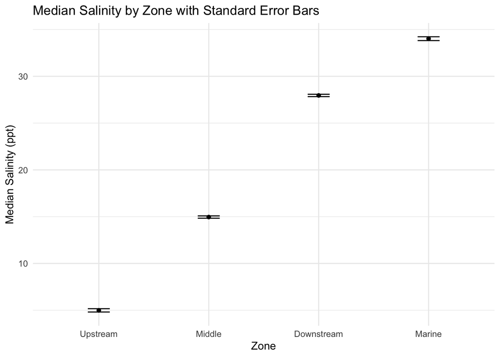

```r
Sal_sum|>
  ggplot(aes(x = zone, y = median_salinity)) +
  geom_point() +
  geom_errorbar(aes(ymin = median_salinity - sem_salinity, ymax = median_salinity + sem_salinity), width = 0.2) +
  theme_minimal() +
  labs(title = "Median Salinity by Zone with Standard Error Bars",
    x = "Zone",
    y = "Median Salinity (ppt)")
```

Calculate the mean and standard error of the fish catch for each scientific speices across esturay zones

```r
fish_stats <- master_set |>
  group_by(zone, scientific_name)|>
  summarise(
    mean_catch = mean(count),
    sem_catch = sd(count)/sqrt(n()),
    .groups = "drop"
  )
```

Make point and error plot

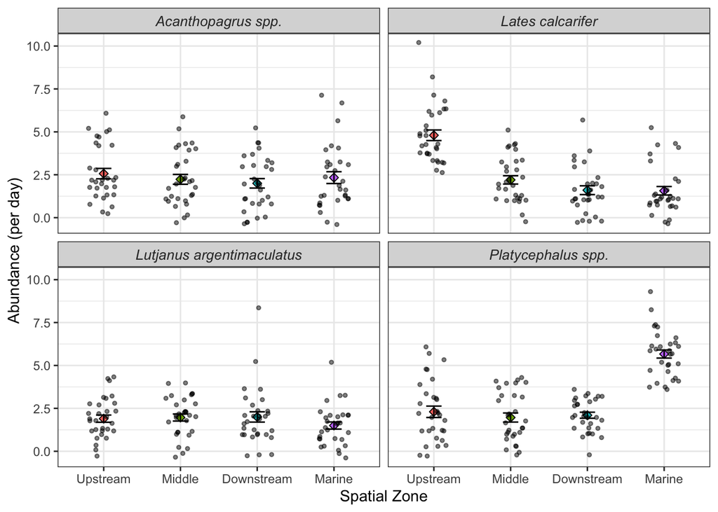

```r
fish_stats |>
  ggplot(aes(x = zone, y = mean_catch, fill = zone)) +
  geom_point(position = "dodge", size = 2, pch = 23) +
  #geom_line(group = 1) +
  geom_errorbar(aes(ymin = mean_catch - sem_catch, ymax = mean_catch + sem_catch),
                position = position_dodge(0.9), width = 0.2) +
  # add in points from master data
  geom_point(data = master_set, aes(x = zone, y = count),
            position = position_jitter(width = 0.2), alpha = 0.5, size = 1, inherit.aes = FALSE) +
  facet_wrap(~ scientific_name, scales = "fixed") +
  theme_bw() +
  theme(
    strip.text = element_text(face = "italic", size = 10, colour = "grey20"),
   # legend.position = "bottom"
    legend.position = "none"
  ) +
  labs(
    #title = "Predatory Fish Abundance across Estuarine Salinity Gradients",
    #subtitle = "Ross River Estuary System, May 2026",
    x = "Spatial Zone",
    y = "Abundance (per day)",
    fill = "Spatial Zone"
  )
```